# HAR Data Analysis

Bernhard Suhm

Thursday, May 14, 2015

## Preparation

(Note to myself for future reference) This work will access the caret package, kernlab (for the spam dataset), and Hmisc. Remember you need two steps, install.packages, followed by library.

We begin by loading the training data set and partitioning it into 60% training and 40% for and cross validation and testing.

```r
nzv_har <- nearZeroVar(train_har,saveMetrics=TRUE)
nzv_har
```

[output not shown]

[output cut: 106 more lines]

[output not shown]

```r
sum(nzv_har$nzv==TRUE)
```

```
## [1] 29
```

```r
train<-train_har[!nzv_har$nzv]
heldout<-heldout_har[!nzv_har$nzv]
testSplit <- createDataPartition(heldout$classe,p=0.5,list=FALSE)
test<-heldout[testSplit,]
crossVal<-heldout[-testSplit,]
```

Then I explored which variables separated the outcome variables visually in plots, only among the non near zero ones. Visually, the following variables had some predictive power: - All three belt (roll, pitch, yaw), max_roll_belt, max_pitch_belt - forearm: pitch and roll though then I realized that all but the 52 “original” data variables (as opposed to those derived applying a window over the original data - thanks to Edward Drake for explaining this so nicely in the discussion forum!) were primarily NA values, hence not suitable for model training. So for the model training phase, we’ll just be using those 52 variables.

## Model Training

First, I wanted to train a linear model, even though my intuition suggested that’s probably not a good fit for this problem. The caret train function had trouble using all variables, but then I used the gbm package and succeeded training a model.

```
## Distribution not specified, assuming multinomial ...
```

The dominant variables in this model by far are roll_belt and pitch_forearm, with some influence by magnet_dumbbell_y, accel_forearm_x, and roll_dumbbell. Only two other variables have non zero influence at all: gyros_dumbbell_y and accel_dumbbel_x. The fact that only 7 out of 52 predictors had a non-zero influence is somewhat disconcerning. Therefore not surprisingly, it’s accuracy is rather low, 50% on the cross validation set. We are even less surprised when we plot the two dominant variables against the classes, we see some nice separation - but clearly not with hyperplanes (linear functions).

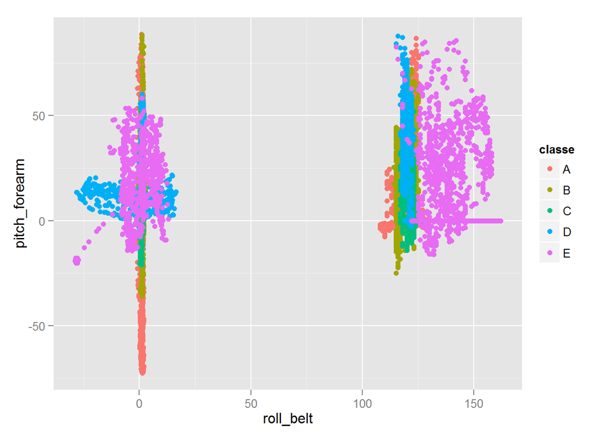

```r
qplot(roll_belt,pitch_forearm,color=classe,data=train)
```

Next I tried LDA, more for practice than seriously expecting it to be the best performer, since I already mentioned earlier the plots aren’t separable by hyperplanes upon visual inspection of some clearly important predictor variables.

This model gets 69.9% accuracy on cross validation. Reducing the variables with PCA (using the preprocessing step that’s built into the caret train package) actually lowers the accuracy to 53.3%.

Next, I trained a random forest on those same 52 variables, using the randomForest package that Bill Howe from University of Washington uses in his Data Science class. It runs a lot faster than the corresponding variant of train in the caret package!

```r
rf_imp <- importance(m_rf)
sort(rf_imp[,1],decreasing=TRUE)
```

```
##            roll_belt             yaw_belt    magnet_dumbbell_z
##            735.20216            542.68701            462.72285
##        pitch_forearm    magnet_dumbbell_y           pitch_belt
##            450.55776            410.75962            391.57163
##         roll_forearm    magnet_dumbbell_x     accel_dumbbell_y
##            362.62132            296.33131            254.63697
##        roll_dumbbell        magnet_belt_y        magnet_belt_z
##            245.25849            238.43009            232.18869
##         accel_belt_z      accel_forearm_x         gyros_belt_z
##            225.60208            203.11306            197.63658
##     accel_dumbbell_z             roll_arm total_accel_dumbbell
##            196.00779            191.44318            162.43434
##         magnet_arm_x     magnet_forearm_z     accel_dumbbell_x
##            162.09256            161.04209            159.35524
##     gyros_dumbbell_y      accel_forearm_z         yaw_dumbbell
##            155.40342            151.78742            149.39110
##        magnet_belt_x     magnet_forearm_x              yaw_arm
##            148.58532            142.22349            139.33484
##          accel_arm_x         magnet_arm_y     magnet_forearm_y
##            138.24212            133.52103            132.12422
##     total_accel_belt         magnet_arm_z       pitch_dumbbell
##            124.21639            109.55618            106.63546
##          yaw_forearm            pitch_arm      accel_forearm_y
##            103.92066            102.73278             92.77681
##          accel_arm_y          gyros_arm_y          accel_arm_z
##             89.47930             82.17348             82.00576
##          gyros_arm_x     gyros_dumbbell_x         gyros_belt_y
##             78.98358             76.98490             76.42158
##         accel_belt_y         accel_belt_x      gyros_forearm_y
##             76.11279             74.89410             74.73835
##  total_accel_forearm      total_accel_arm         gyros_belt_x
##             69.24118             64.40825             61.16270
##     gyros_dumbbell_z      gyros_forearm_z      gyros_forearm_x
##             53.06391             52.72239             47.59533
##          gyros_arm_z
##             37.08750
```

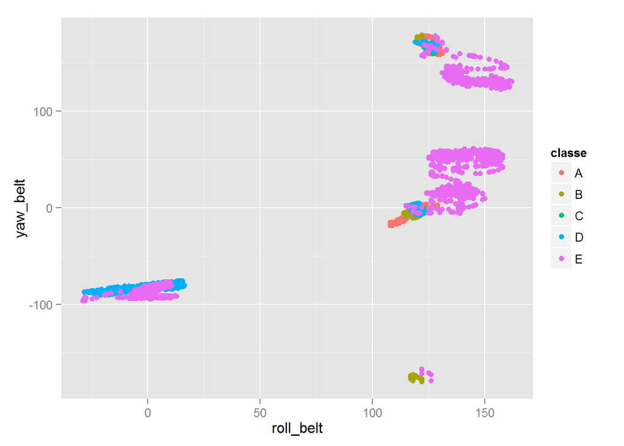

```r
qplot(roll_belt,yaw_belt,color=classe,data=train)
```

## Model Evaluation

```r
HAR_test <- read.csv("pml-testing.csv", na.string=c("NA","#DIV/0!"))
clean_test <- HAR_test[,8:160]
p_test <- predict(m_rf,clean_test,type="class")
acc_test <- sum(p_test==clean_test$classe)/20
```